# Desigualdades Educacionais: Amazônia Legal vs. Restante do Brasil

Análise Comparativa Multidimensional - Rede Pública - Censo Escolar 2025

# Introdução

Este relatório apresenta uma análise comparativa abrangente das desigualdades educacionais entre a **Amazônia Legal** e o **restante do Brasil**, utilizando os microdados do **Censo Escolar 2025** publicados pelo INEP. A delimitação da Amazônia Legal foi feita **no nível municipal**, utilizando a classificação oficial do IBGE presente na base de dados do PIB dos Municípios 2010-2023, que identifica cada um dos **772 municípios** que compõem a região. Essa abordagem é mais precisa do que a simples classificação por UF, pois estados como o Maranhão possuem apenas parte de seus municípios dentro da Amazônia Legal (181 dos 217 municípios maranhenses).

A análise percorre múltiplas dimensões: infraestrutura, saneamento, equipamentos, tecnologia, perfil docente, gestores, matrículas, turmas, modalidades e materiais pedagógicos. Cada tabela é ordenada pelo tamanho do gap (maior diferença primeiro), e barras visuais mostram a comparação proporcional.

```
## Municípios classificados como Amazônia Legal: 772
```

```
## Escolas na Amazônia Legal: 30668
```

```
## Escolas no Restante do País: 107418
```

**Universo da análise:** O Censo Escolar 2025 registra **138.086** escolas em funcionamento no Brasil. Destas, **30.668** (22,2%) estão na Amazônia Legal e **107.418** (77,8%) no restante do país. Nas tabelas, as barras mostram ■ Amazônia Legal e ■ Restante do País. As tabelas são ordenadas pelo tamanho do gap (maior diferença primeiro).

# 1. Panorama Geral: Distribuição das Escolas

Distribuição das Escolas por Dependência Administrativa

| Dependência Administrativa | N Amazônia | N Restante | % Amazônia | % Restante | Diferença (p.p.) |
| --- | --- | --- | --- | --- | --- |
| Municipal | 25.019 | 82.353 | 81,6% | 76,7% | +4,9 p.p. |
| Estadual | 5.520 | 24.478 | 18,0% | 22,8% | -4,8 p.p. |
| Federal | 129 | 587 | 0,4% | 0,5% | -0,1 p.p. |

Distribuição das Escolas por Localização

| Localização | N Amazônia | N Restante | % Amazônia | % Restante | Diferença (p.p.) |
| --- | --- | --- | --- | --- | --- |
| Rural | 19.388 | 30.705 | 63,2% | 28,6% | +34,6 p.p. |
| Urbana | 11.280 | 76.713 | 36,8% | 71,4% | -34,6 p.p. |

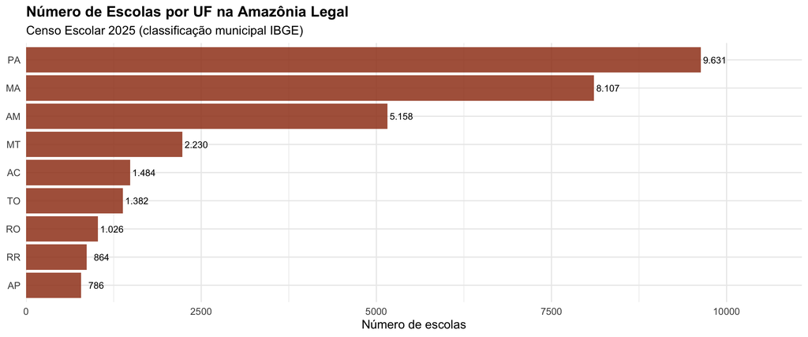

# 2. Infraestrutura Escolar

## 2.1 Dependências e Espaços Físicos

Proporção de Escolas com Dependências Físicas — % de escolas que possuem cada espaço

| Indicador | Quantitativo Absoluto N (Amaz.) | Quantitativo Absoluto N (Rest.) | Proporção / Média Amazônia Legal | Proporção / Média Restante do País | Proporção / Média Brasil | Gap Diferença | Comparação |
| --- | --- | --- | --- | --- | --- | --- | --- |
| Banheiro funcionários | 12.542 | 78.382 | 40,9% | 73,0% | 65,8% | -32,1 p.p. |  |
| Almoxarifado | 8.242 | 62.832 | 26,9% | 58,5% | 51,5% | -31,6 p.p. |  |
| Pátio descoberto | 7.597 | 59.152 | 24,8% | 55,1% | 48,3% | -30,3 p.p. |  |
| Sala de professores | 13.477 | 76.971 | 43,9% | 71,7% | 65,5% | -27,7 p.p. |  |
| Biblioteca ou sala de leitura | 9.693 | 61.892 | 31,6% | 57,6% | 51,8% | -26,0 p.p. |  |
| Sala de diretoria | 15.861 | 83.322 | 51,7% | 77,6% | 71,8% | -25,8 p.p. |  |
| Parque infantil | 3.472 | 39.355 | 11,3% | 36,6% | 31,0% | -25,3 p.p. |  |
| Quadra de esportes (qualquer) | 6.381 | 46.945 | 20,8% | 43,7% | 38,6% | -22,9 p.p. |  |
| Refeitório | 11.802 | 65.606 | 38,5% | 61,1% | 56,1% | -22,6 p.p. |  |
| Banheiro PNE/acessível | 11.480 | 64.170 | 37,4% | 59,7% | 54,8% | -22,3 p.p. |  |
| Banheiro ed. infantil | 5.524 | 39.920 | 18,0% | 37,2% | 32,9% | -19,2 p.p. |  |
| Laboratório de informática | 4.287 | 34.678 | 14,0% | 32,3% | 28,2% | -18,3 p.p. |  |
| Quadra coberta | 4.978 | 36.989 | 16,2% | 34,4% | 30,4% | -18,2 p.p. |  |
| Pátio coberto | 13.468 | 65.126 | 43,9% | 60,6% | 56,9% | -16,7 p.p. |  |
| Despensa | 19.141 | 84.960 | 62,4% | 79,1% | 75,4% | -16,7 p.p. |  |
| Secretaria | 18.784 | 83.550 | 61,2% | 77,8% | 74,1% | -16,5 p.p. |  |
| Banheiro com chuveiro | 8.872 | 48.237 | 28,9% | 44,9% | 41,4% | -16,0 p.p. |  |
| Biblioteca | 6.159 | 38.138 | 20,1% | 35,5% | 32,1% | -15,4 p.p. |  |
| Sala de leitura | 5.150 | 33.082 | 16,8% | 30,8% | 27,7% | -14,0 p.p. |  |
| Sala atend. especial/AEE | 7.535 | 40.097 | 24,6% | 37,3% | 34,5% | -12,8 p.p. |  |
| Terreirão | 7.974 | 16.958 | 26,0% | 15,8% | 18,1% | +10,2 p.p. |  |
| Quadra descoberta | 1.780 | 16.088 | 5,8% | 15,0% | 12,9% | -9,2 p.p. |  |
| Banheiro | 27.802 | 106.530 | 90,7% | 99,2% | 97,3% | -8,5 p.p. |  |
| Laboratório de ciências | 1.818 | 14.232 | 5,9% | 13,2% | 11,6% | -7,3 p.p. |  |
| Sala multiuso | 888 | 9.692 | 2,9% | 9,0% | 7,7% | -6,1 p.p. |  |
| Área de plantio | 2.687 | 15.938 | 8,8% | 14,8% | 13,5% | -6,1 p.p. |  |
| Área verde | 9.771 | 40.155 | 31,9% | 37,4% | 36,2% | -5,5 p.p. |  |
| Cozinha | 28.507 | 105.207 | 93,0% | 97,9% | 96,8% | -5,0 p.p. |  |
| Auditório | 2.230 | 12.479 | 7,3% | 11,6% | 10,7% | -4,3 p.p. |  |
| Sala/ateliê de artes | 215 | 4.831 | 0,7% | 4,5% | 3,7% | -3,8 p.p. |  |
| Dormitório professor | 1.101 | 422 | 3,6% | 0,4% | 1,1% | +3,2 p.p. |  |
| Sala de repouso aluno | 480 | 4.361 | 1,6% | 4,1% | 3,5% | -2,5 p.p. |  |
| Laboratório ed. profissional | 210 | 1.999 | 0,7% | 1,9% | 1,6% | -1,2 p.p. |  |
| Dormitório aluno | 415 | 2.712 | 1,4% | 2,5% | 2,3% | -1,2 p.p. |  |
| Sala de música/coral | 285 | 1.766 | 0,9% | 1,6% | 1,5% | -0,7 p.p. |  |
| Estúdio de dança | 126 | 955 | 0,4% | 0,9% | 0,8% | -0,5 p.p. |  |
| Sala oficinas ed. profissional | 149 | 856 | 0,5% | 0,8% | 0,7% | -0,3 p.p. |  |
| Viveiro | 132 | 716 | 0,4% | 0,7% | 0,6% | -0,2 p.p. |  |
| Piscina | 223 | 960 | 0,7% | 0,9% | 0,9% | -0,2 p.p. |  |
| Estúdio de gravação | 65 | 338 | 0,2% | 0,3% | 0,3% | -0,1 p.p. |  |

## 2.2 Abastecimento de Água

Abastecimento de Água nas Escolas — % de escolas por fonte de água

| Indicador | Quantitativo Absoluto N (Amaz.) | Quantitativo Absoluto N (Rest.) | Proporção / Média Amazônia Legal | Proporção / Média Restante do País | Proporção / Média Brasil | Gap Diferença | Comparação |
| --- | --- | --- | --- | --- | --- | --- | --- |
| Rede pública | 12.671 | 88.817 | 41,3% | 82,7% | 73,5% | -41,4 p.p. |  |
| Poço artesiano | 12.729 | 13.403 | 41,5% | 12,5% | 18,9% | +29,0 p.p. |  |
| Água potável | 26.295 | 105.975 | 85,7% | 98,7% | 95,8% | -12,9 p.p. |  |
| Fonte/rio/igarapé | 4.373 | 2.022 | 14,3% | 1,9% | 4,6% | +12,4 p.p. |  |
| Carro-pipa | 325 | 5.556 | 1,1% | 5,2% | 4,3% | -4,1 p.p. |  |
| Água inexistente | 1.052 | 151 | 3,4% | 0,1% | 0,9% | +3,3 p.p. |  |
| Cacimba/cisterna | 2.887 | 9.885 | 9,4% | 9,2% | 9,2% | +0,2 p.p. |  |

## 2.3 Energia Elétrica

Fornecimento de Energia Elétrica — % de escolas por fonte de energia

| Indicador | Quantitativo Absoluto N (Amaz.) | Quantitativo Absoluto N (Rest.) | Proporção / Média Amazônia Legal | Proporção / Média Restante do País | Proporção / Média Brasil | Gap Diferença | Comparação |
| --- | --- | --- | --- | --- | --- | --- | --- |
| Rede pública | 26.117 | 107.072 | 85,2% | 99,7% | 96,5% | -14,5 p.p. |  |
| Energia inexistente | 1.696 | 78 | 5,5% | 0,1% | 1,3% | +5,5 p.p. |  |
| Gerador (combustível fóssil) | 1.560 | 122 | 5,1% | 0,1% | 1,2% | +5,0 p.p. |  |
| Energia renovável (solar/eólica) | 2.087 | 2.178 | 6,8% | 2,0% | 3,1% | +4,8 p.p. |  |

## 2.4 Esgotamento Sanitário

Esgotamento Sanitário — % de escolas por tipo de esgoto

| Indicador | Quantitativo Absoluto N (Amaz.) | Quantitativo Absoluto N (Rest.) | Proporção / Média Amazônia Legal | Proporção / Média Restante do País | Proporção / Média Brasil | Gap Diferença | Comparação |
| --- | --- | --- | --- | --- | --- | --- | --- |
| Rede pública de esgoto | 3.232 | 64.201 | 10,5% | 59,8% | 48,8% | -49,2 p.p. |  |
| Fossa (qualquer tipo) | 24.284 | 45.774 | 79,2% | 42,6% | 50,7% | +36,6 p.p. |  |
| Fossa comum/rudimentar | 12.301 | 18.578 | 40,1% | 17,3% | 22,4% | +22,8 p.p. |  |
| Fossa séptica | 11.983 | 27.196 | 39,1% | 25,3% | 28,4% | +13,8 p.p. |  |
| Esgoto inexistente | 3.626 | 907 | 11,8% | 0,8% | 3,3% | +11,0 p.p. |  |

## 2.5 Destinação do Lixo

Destinação e Tratamento do Lixo — % de escolas por tipo de destinação

| Indicador | Quantitativo Absoluto N (Amaz.) | Quantitativo Absoluto N (Rest.) | Proporção / Média Amazônia Legal | Proporção / Média Restante do País | Proporção / Média Brasil | Gap Diferença | Comparação |
| --- | --- | --- | --- | --- | --- | --- | --- |
| Serviço de coleta | 15.209 | 96.160 | 49,6% | 89,5% | 80,7% | -39,9 p.p. |  |
| Queima | 14.643 | 11.133 | 47,7% | 10,4% | 18,7% | +37,4 p.p. |  |
| Tratamento inexistente | 25.112 | 61.113 | 81,9% | 56,9% | 62,4% | +25,0 p.p. |  |
| Separação de lixo | 4.747 | 41.473 | 15,5% | 38,6% | 33,5% | -23,1 p.p. |  |
| Descarte em outra área | 4.881 | 1.536 | 15,9% | 1,4% | 4,6% | +14,5 p.p. |  |
| Reciclagem | 893 | 12.520 | 2,9% | 11,7% | 9,7% | -8,7 p.p. |  |
| Enterramento | 2.689 | 1.486 | 8,8% | 1,4% | 3,0% | +7,4 p.p. |  |
| Destino final público | 489 | 3.335 | 1,6% | 3,1% | 2,8% | -1,5 p.p. |  |
| Reutilização | 1.058 | 4.338 | 3,4% | 4,0% | 3,9% | -0,6 p.p. |  |

## 2.6 Acessibilidade

Acessibilidade nas Escolas — % de escolas com recursos de acessibilidade

| Indicador | Quantitativo Absoluto N (Amaz.) | Quantitativo Absoluto N (Rest.) | Proporção / Média Amazônia Legal | Proporção / Média Restante do País | Proporção / Média Brasil | Gap Diferença | Comparação |
| --- | --- | --- | --- | --- | --- | --- | --- |
| Corrimão | 4.323 | 39.733 | 14,1% | 37,0% | 31,9% | -22,9 p.p. |  |
| Acessibilidade inexistente | 12.470 | 19.901 | 40,7% | 18,5% | 23,4% | +22,1 p.p. |  |
| Rampas | 14.017 | 70.032 | 45,7% | 65,2% | 60,9% | -19,5 p.p. |  |
| Vão livre (>80cm) | 10.925 | 56.794 | 35,6% | 52,9% | 49,0% | -17,2 p.p. |  |
| Pisos táteis | 2.076 | 13.925 | 6,8% | 13,0% | 11,6% | -6,2 p.p. |  |
| Sinal visual | 1.285 | 9.355 | 4,2% | 8,7% | 7,7% | -4,5 p.p. |  |
| Elevador | 190 | 4.336 | 0,6% | 4,0% | 3,3% | -3,4 p.p. |  |
| Sinal tátil | 853 | 6.139 | 2,8% | 5,7% | 5,1% | -2,9 p.p. |  |
| Sinal sonoro | 491 | 4.106 | 1,6% | 3,8% | 3,3% | -2,2 p.p. |  |
| Sinalização | 315 | 2.705 | 1,0% | 2,5% | 2,2% | -1,5 p.p. |  |

## 2.7 Salas de Aula

Salas de Aula — Médias por Escola — Quantidade média de salas por escola

| Indicador | Quantitativo Absoluto N (Amaz.) | Quantitativo Absoluto N (Rest.) | Proporção / Média Amazônia Legal | Proporção / Média Restante do País | Proporção / Média Brasil | Gap Diferença | Comparação |
| --- | --- | --- | --- | --- | --- | --- | --- |
| Salas dentro do prédio | 172.315 | 903.388 | 5,62 | 8,41 | 7,79 | -2,79 |  |
| Total de salas utilizadas | 192.237 | 954.267 | 6,27 | 8,88 | 8,30 | -2,62 |  |
| Salas acessíveis PNE | 55.099 | 347.144 | 1,80 | 3,23 | 2,91 | -1,44 |  |
| Salas climatizadas | 119.794 | 392.746 | 3,91 | 3,66 | 3,71 | 0,25 |  |
| Salas fora do prédio | 19.922 | 50.879 | 0,65 | 0,47 | 0,51 | 0,18 |  |

Proporção Média de Salas Climatizadas e Acessíveis (entre escolas com salas)

| REGIAO_ESTUDO | n_escolas | Média % climatizadas | Média % acessíveis |
| --- | --- | --- | --- |
| Amazônia Legal | 30.668 | 45,1% | 18,9% |
| Restante do País | 107.418 | 39,8% | 32,9% |

# 3. Equipamentos e Tecnologia

## 3.1 Equipamentos Disponíveis

Equipamentos nas Escolas — % de escolas que possuem cada equipamento

| Indicador | Quantitativo Absoluto N (Amaz.) | Quantitativo Absoluto N (Rest.) | Proporção / Média Amazônia Legal | Proporção / Média Restante do País | Proporção / Média Brasil | Gap Diferença | Comparação |
| --- | --- | --- | --- | --- | --- | --- | --- |
| Televisão | 15.065 | 91.623 | 49,1% | 85,3% | 77,3% | -36,2 p.p. |  |
| Equipamento de som | 12.966 | 82.573 | 42,3% | 76,9% | 69,2% | -34,6 p.p. |  |
| Impressora multifuncional | 14.087 | 83.410 | 45,9% | 77,6% | 70,6% | -31,7 p.p. |  |
| Computador | 18.124 | 95.791 | 59,1% | 89,2% | 82,5% | -30,1 p.p. |  |
| Notebook para aluno | 7.727 | 53.142 | 25,2% | 49,5% | 44,1% | -24,3 p.p. |  |
| Projetor multimídia | 14.588 | 77.003 | 47,6% | 71,7% | 66,3% | -24,1 p.p. |  |
| Copiadora | 3.869 | 36.157 | 12,6% | 33,7% | 29,0% | -21,0 p.p. |  |
| DVD | 3.727 | 35.386 | 12,2% | 32,9% | 28,3% | -20,8 p.p. |  |
| Desktop para aluno | 9.123 | 54.136 | 29,7% | 50,4% | 45,8% | -20,6 p.p. |  |
| Nenhum equipamento | 7.201 | 3.825 | 23,5% | 3,6% | 8,0% | +19,9 p.p. |  |
| Tablet para aluno | 2.729 | 30.213 | 8,9% | 28,1% | 23,9% | -19,2 p.p. |  |
| Impressora | 14.470 | 69.093 | 47,2% | 64,3% | 60,5% | -17,1 p.p. |  |
| Scanner | 2.832 | 27.082 | 9,2% | 25,2% | 21,7% | -16,0 p.p. |  |
| Lousa digital | 1.573 | 21.938 | 5,1% | 20,4% | 17,0% | -15,3 p.p. |  |
| Antena parabólica | 971 | 6.526 | 3,2% | 6,1% | 5,4% | -2,9 p.p. |  |

## 3.2 Quantidade de Equipamentos (Médias)

Quantidade Média de Equipamentos por Escola

| Indicador | Quantitativo Absoluto N (Amaz.) | Quantitativo Absoluto N (Rest.) | Proporção / Média Amazônia Legal | Proporção / Média Restante do País | Proporção / Média Brasil | Gap Diferença | Comparação |
| --- | --- | --- | --- | --- | --- | --- | --- |
| TVs | 6.529.331 | 146.675.792 | 212,90 | 1.365,47 | 1.109,49 | -1152,56 |  |
| Projetores multimídia | 2.518.773 | 77.195.140 | 82,13 | 718,64 | 577,28 | -636,51 |  |
| Equipamentos de som | 1.266.965 | 65.994.831 | 41,31 | 614,37 | 487,10 | -573,06 |  |
| Tablets para alunos | 416.668 | 7.946.137 | 13,59 | 73,97 | 60,56 | -60,39 |  |
| DVDs | 95.049 | 5.227.479 | 3,10 | 48,66 | 38,55 | -45,57 |  |
| Notebooks para alunos | 1.856.631 | 11.026.203 | 60,54 | 102,65 | 93,30 | -42,11 |  |
| Lousas digitais | 92.652 | 4.325.436 | 3,02 | 40,27 | 32,00 | -37,25 |  |
| Desktops para alunos | 510.783 | 5.249.405 | 16,66 | 48,87 | 41,71 | -32,21 |  |

## 3.3 Internet e Conectividade

Internet e Conectividade — % de escolas com acesso à internet

| Indicador | Quantitativo Absoluto N (Amaz.) | Quantitativo Absoluto N (Rest.) | Proporção / Média Amazônia Legal | Proporção / Média Restante do País | Proporção / Média Brasil | Gap Diferença | Comparação |
| --- | --- | --- | --- | --- | --- | --- | --- |
| Internet para aprendizagem | 14.545 | 87.090 | 47,4% | 81,1% | 73,6% | -33,6 p.p. |  |
| Banda larga | 19.049 | 92.235 | 62,1% | 85,9% | 80,6% | -23,8 p.p. |  |
| Internet administrativo | 22.601 | 102.119 | 73,7% | 95,1% | 90,3% | -21,4 p.p. |  |
| Acesso via computador | 5.860 | 42.876 | 19,1% | 39,9% | 35,3% | -20,8 p.p. |  |
| Internet (qualquer) | 23.960 | 104.654 | 78,1% | 97,4% | 93,1% | -19,3 p.p. |  |
| Internet para alunos | 8.452 | 50.274 | 27,6% | 46,8% | 42,5% | -19,2 p.p. |  |
| Internet para comunidade | 2.604 | 7.339 | 8,5% | 6,8% | 7,2% | +1,7 p.p. |  |
| Acesso via dispositivos pessoais | 5.244 | 18.464 | 17,1% | 17,2% | 17,2% | -0,1 p.p. |  |

# 4. Recursos Humanos Não-Docentes

Profissionais Não-Docentes — Média por Escola

| Indicador | Quantitativo Absoluto N (Amaz.) | Quantitativo Absoluto N (Rest.) | Proporção / Média Amazônia Legal | Proporção / Média Restante do País | Proporção / Média Brasil | Gap Diferença | Comparação |
| --- | --- | --- | --- | --- | --- | --- | --- |
| Monitores | 1.695.412 | 64.129.185 | 55,28 | 597,01 | 476,69 | -541,72 |  |
| Pedagogia | 6.705.965 | 40.734.608 | 218,66 | 379,22 | 343,56 | -160,55 |  |
| Administrativos | 1.365.804 | 19.369.763 | 44,54 | 180,32 | 150,16 | -135,79 |  |
| Profissional de saúde | 445.773 | 15.650.008 | 14,54 | 145,69 | 116,56 | -131,16 |  |
| Serviços gerais | 11.501.480 | 27.326.309 | 375,03 | 254,39 | 281,19 | 120,64 |  |
| Assistente social | 2.402.618 | 1.525.164 | 78,34 | 14,20 | 28,44 | 64,14 |  |
| Nutricionista | 2.402.437 | 2.166.415 | 78,34 | 20,17 | 33,09 | 58,17 |  |
| Coordenador | 185.359 | 6.641.902 | 6,04 | 61,83 | 49,44 | -55,79 |  |
| Psicólogo | 180.499 | 4.024.235 | 5,89 | 37,46 | 30,45 | -31,58 |  |
| Segurança | 9.977.720 | 37.835.494 | 325,35 | 352,23 | 346,26 | -26,88 |  |
| Secretário escolar | 103.806 | 1.407.111 | 3,38 | 13,10 | 10,94 | -9,71 |  |
| Bibliotecário | 1.340.024 | 5.464.058 | 43,69 | 50,87 | 49,27 | -7,17 |  |
| Tradutor/intérprete de Libras | 711.853 | 1.959.331 | 23,21 | 18,24 | 19,34 | 4,97 |  |
| Profissional agrícola | 178.783 | 1.158.948 | 5,83 | 10,79 | 9,69 | -4,96 |  |
| Revisor de Braille | 177.916 | 178.207 | 5,80 | 1,66 | 2,58 | 4,14 |  |
| Fonoaudiólogo | 312 | 270.546 | 0,01 | 2,52 | 1,96 | -2,51 |  |
| Gestão | 191.762 | 709.579 | 6,25 | 6,61 | 6,53 | -0,35 |  |
| Alimentação escolar | 2.192.141 | 7.646.686 | 71,48 | 71,19 | 71,25 | 0,29 |  |

# 5. Material Pedagógico e Programas

## 5.1 Materiais Pedagógicos

Materiais Pedagógicos Especializados — % de escolas que possuem cada tipo de material

| Indicador | Quantitativo Absoluto N (Amaz.) | Quantitativo Absoluto N (Rest.) | Proporção / Média Amazônia Legal | Proporção / Média Restante do País | Proporção / Média Brasil | Gap Diferença | Comparação |
| --- | --- | --- | --- | --- | --- | --- | --- |
| Difusão/divulgação | 7.986 | 65.746 | 26,0% | 61,2% | 53,4% | -35,2 p.p. |  |
| Desportiva | 12.716 | 78.011 | 41,5% | 72,6% | 65,7% | -31,2 p.p. |  |
| Artísticas | 4.925 | 50.035 | 16,1% | 46,6% | 39,8% | -30,5 p.p. |  |
| Jogos educativos | 18.949 | 92.905 | 61,8% | 86,5% | 81,0% | -24,7 p.p. |  |
| Multimídia | 4.581 | 42.466 | 14,9% | 39,5% | 34,1% | -24,6 p.p. |  |
| Educação infantil | 9.161 | 55.515 | 29,9% | 51,7% | 46,8% | -21,8 p.p. |  |
| Étnico-racial | 2.363 | 29.053 | 7,7% | 27,0% | 22,8% | -19,3 p.p. |  |
| Nenhum material pedagógico | 6.560 | 5.014 | 21,4% | 4,7% | 8,4% | +16,7 p.p. |  |
| Educação especial | 5.117 | 35.751 | 16,7% | 33,3% | 29,6% | -16,6 p.p. |  |
| Musical | 3.590 | 30.155 | 11,7% | 28,1% | 24,4% | -16,4 p.p. |  |
| Científico | 1.984 | 20.925 | 6,5% | 19,5% | 16,6% | -13,0 p.p. |  |
| Agrícola | 1.416 | 10.448 | 4,6% | 9,7% | 8,6% | -5,1 p.p. |  |
| Campo | 2.635 | 6.387 | 8,6% | 5,9% | 6,5% | +2,6 p.p. |  |
| Profissional | 841 | 5.529 | 2,7% | 5,1% | 4,6% | -2,4 p.p. |  |
| Indígena | 1.168 | 2.010 | 3,8% | 1,9% | 2,3% | +1,9 p.p. |  |
| Bilíngue para surdos | 809 | 4.402 | 2,6% | 4,1% | 3,8% | -1,5 p.p. |  |
| Quilombola | 203 | 1.454 | 0,7% | 1,4% | 1,2% | -0,7 p.p. |  |

## 5.2 Alimentação e Educação Ambiental

Alimentação Escolar e Educação Ambiental

| Indicador | Quantitativo Absoluto N (Amaz.) | Quantitativo Absoluto N (Rest.) | Proporção / Média Amazônia Legal | Proporção / Média Restante do País | Proporção / Média Brasil | Gap Diferença | Comparação |
| --- | --- | --- | --- | --- | --- | --- | --- |
| Ed. ambiental — projetos | 9.359 | 47.318 | 30,5% | 44,1% | 41,0% | -13,5 p.p. |  |
| Ed. ambiental — conteúdo transversal | 7.054 | 37.186 | 23,0% | 34,6% | 32,0% | -11,6 p.p. |  |
| Educação ambiental (qualquer) | 15.267 | 63.978 | 49,8% | 59,6% | 57,4% | -9,8 p.p. |  |
| Ed. ambiental — componente curricular | 1.865 | 9.237 | 6,1% | 8,6% | 8,0% | -2,5 p.p. |  |
| Ed. ambiental — eixo temático | 2.076 | 9.038 | 6,8% | 8,4% | 8,0% | -1,6 p.p. |  |
| Ed. ambiental — eventos | 7.644 | 28.151 | 24,9% | 26,2% | 25,9% | -1,3 p.p. |  |
| Alimentação escolar | 30.482 | 106.515 | 99,4% | 99,2% | 99,2% | +0,2 p.p. |  |
| Ed. ambiental — nenhuma ação | 227 | 670 | 0,7% | 0,6% | 0,6% | +0,1 p.p. |  |

## 5.3 Órgãos Colegiados e Participação

Órgãos Colegiados e Participação Social

| Indicador | Quantitativo Absoluto N (Amaz.) | Quantitativo Absoluto N (Rest.) | Proporção / Média Amazônia Legal | Proporção / Média Restante do País | Proporção / Média Brasil | Gap Diferença | Comparação |
| --- | --- | --- | --- | --- | --- | --- | --- |
| Redes sociais | 9.748 | 69.426 | 31,8% | 64,6% | 57,3% | -32,8 p.p. |  |
| Associação de pais e mestres | 3.501 | 43.627 | 11,4% | 40,6% | 34,1% | -29,2 p.p. |  |
| Conselho escolar | 19.601 | 88.937 | 63,9% | 82,8% | 78,6% | -18,9 p.p. |  |
| Nenhum órgão colegiado | 8.361 | 9.409 | 27,3% | 8,8% | 12,9% | +18,5 p.p. |  |
| Grêmio estudantil | 2.354 | 19.117 | 7,7% | 17,8% | 15,5% | -10,1 p.p. |  |
| Outros órgãos | 1.474 | 10.077 | 4,8% | 9,4% | 8,4% | -4,6 p.p. |  |
| Associação de pais | 443 | 4.326 | 1,4% | 4,0% | 3,5% | -2,6 p.p. |  |

# 6. Perfil e Formação Docente

## 6.1 Quantidade de Docentes por Etapa

Quantidade Média de Docentes por Escola e Etapa

| Indicador | Quantitativo Absoluto N (Amaz.) | Quantitativo Absoluto N (Rest.) | Proporção / Média Amazônia Legal | Proporção / Média Restante do País | Proporção / Média Brasil | Gap Diferença | Comparação |
| --- | --- | --- | --- | --- | --- | --- | --- |
| Ed. Básica (total) | 363.547 | 1.976.843 | 11,90 | 18,57 | 17,08 | -6,67 |  |
| Fundamental (total) | 223.453 | 1.128.191 | 7,31 | 10,60 | 9,86 | -3,28 |  |
| Ed. Infantil (total) | 68.062 | 472.509 | 2,23 | 4,44 | 3,95 | -2,21 |  |
| Fund. Anos Iniciais | 100.188 | 575.455 | 3,28 | 5,40 | 4,93 | -2,13 |  |
| Ensino Médio | 73.129 | 456.899 | 2,39 | 4,29 | 3,87 | -1,90 |  |
| Creche | 26.941 | 242.006 | 0,88 | 2,27 | 1,96 | -1,39 |  |
| Fund. Anos Finais | 132.863 | 604.020 | 4,35 | 5,67 | 5,38 | -1,32 |  |
| Ed. Profissional | 26.539 | 206.775 | 0,87 | 1,94 | 1,70 | -1,07 |  |
| Pré-escola | 43.157 | 252.951 | 1,41 | 2,38 | 2,16 | -0,96 |  |
| EJA | 36.194 | 165.925 | 1,18 | 1,56 | 1,48 | -0,37 |  |

## 6.2 Escolaridade dos Docentes

Escolaridade dos Docentes da Educação Básica — % em relação ao total de docentes (agregado)

| Indicador | Quantitativo Absoluto N (Amaz.) | Quantitativo Absoluto N (Rest.) | Proporção / Média Amazônia Legal | Proporção / Média Restante do País | Proporção / Média Brasil | Gap Diferença | Comparação |
| --- | --- | --- | --- | --- | --- | --- | --- |
| Pós — Especialização | 159.821 | 1.054.185 | 44,0% | 53,3% | 51,9% | -9,4 p.p. |  |
| Superior — Graduação | 307.547 | 1.826.943 | 84,6% | 92,4% | 91,2% | -7,8 p.p. |  |
| Ensino Médio | 55.041 | 148.289 | 15,1% | 7,5% | 8,7% | +7,6 p.p. |  |
| Superior — Licenciatura | 297.820 | 1.768.417 | 81,9% | 89,5% | 88,3% | -7,5 p.p. |  |
| Pós — Nenhuma | 137.761 | 698.797 | 37,9% | 35,3% | 35,7% | +2,5 p.p. |  |
| Pós — Mestrado | 14.135 | 95.913 | 3,9% | 4,9% | 4,7% | -1,0 p.p. |  |
| Pós — Doutorado | 3.033 | 26.281 | 0,8% | 1,3% | 1,3% | -0,5 p.p. |  |
| Superior — Sem licenciatura | 11.522 | 68.448 | 3,2% | 3,5% | 3,4% | -0,3 p.p. |  |
| Ensino Fundamental | 959 | 1.611 | 0,3% | 0,1% | 0,1% | +0,2 p.p. |  |

## 6.3 Vínculo Empregatício dos Docentes

Vínculo Empregatício dos Docentes — % em relação ao total de docentes (agregado)

| Indicador | Quantitativo Absoluto N (Amaz.) | Quantitativo Absoluto N (Rest.) | Proporção / Média Amazônia Legal | Proporção / Média Restante do País | Proporção / Média Brasil | Gap Diferença | Comparação |
| --- | --- | --- | --- | --- | --- | --- | --- |
| Contrato temporário | 174.741 | 792.858 | 48,1% | 40,1% | 41,3% | +8,0 p.p. |  |
| Concursado/efetivo | 192.659 | 1.150.730 | 53,0% | 58,2% | 57,4% | -5,2 p.p. |  |
| CLT | 1.845 | 40.466 | 0,5% | 2,0% | 1,8% | -1,5 p.p. |  |
| Terceirizado | 751 | 15.152 | 0,2% | 0,8% | 0,7% | -0,6 p.p. |  |

## 6.4 Perfil Demográfico dos Docentes

Perfil Demográfico dos Docentes — % em relação ao total de docentes (agregado)

| Indicador | Quantitativo Absoluto N (Amaz.) | Quantitativo Absoluto N (Rest.) | Proporção / Média Amazônia Legal | Proporção / Média Restante do País | Proporção / Média Brasil | Gap Diferença | Comparação |
| --- | --- | --- | --- | --- | --- | --- | --- |
| Branca | 53.189 | 959.088 | 14,6% | 48,5% | 43,3% | -33,9 p.p. |  |
| Parda | 200.883 | 579.633 | 55,3% | 29,3% | 33,3% | +25,9 p.p. |  |
| Masculino | 112.610 | 457.396 | 31,0% | 23,1% | 24,4% | +7,8 p.p. |  |
| Feminino | 250.937 | 1.519.447 | 69,0% | 76,9% | 75,6% | -7,8 p.p. |  |
| Indígena | 13.878 | 9.424 | 3,8% | 0,5% | 1,0% | +3,3 p.p. |  |
| Preta | 20.813 | 126.535 | 5,7% | 6,4% | 6,3% | -0,7 p.p. |  |
| PcD | 1.618 | 10.688 | 0,4% | 0,5% | 0,5% | -0,1 p.p. |  |

# 7. Perfil dos Gestores Escolares

## 7.1 Escolaridade dos Gestores

Escolaridade dos Gestores Escolares — % em relação ao total de gestores (agregado)

| Indicador | Quantitativo Absoluto N (Amaz.) | Quantitativo Absoluto N (Rest.) | Proporção / Média Amazônia Legal | Proporção / Média Restante do País | Proporção / Média Brasil | Gap Diferença | Comparação |
| --- | --- | --- | --- | --- | --- | --- | --- |
| Pós — Especialização | 17.113 | 82.500 | 54,1% | 71,9% | 68,1% | -17,8 p.p. |  |
| Superior — Licenciatura | 24.287 | 100.940 | 76,8% | 88,0% | 85,6% | -11,1 p.p. |  |
| Superior — Graduação | 26.885 | 108.966 | 85,1% | 95,0% | 92,8% | -9,9 p.p. |  |
| Ensino Médio | 4.636 | 5.686 | 14,7% | 5,0% | 7,1% | +9,7 p.p. |  |
| Pós — Nenhuma pós | 8.793 | 22.869 | 27,8% | 19,9% | 21,6% | +7,9 p.p. |  |
| Superior — Sem licenciatura | 2.598 | 8.026 | 8,2% | 7,0% | 7,3% | +1,2 p.p. |  |
| Pós — Mestrado | 1.425 | 6.060 | 4,5% | 5,3% | 5,1% | -0,8 p.p. |  |
| Pós — Doutorado | 195 | 1.127 | 0,6% | 1,0% | 0,9% | -0,4 p.p. |  |
| Ensino Fundamental | 85 | 68 | 0,3% | 0,1% | 0,1% | +0,2 p.p. |  |

## 7.2 Vínculo e Acesso ao Cargo

Vínculo Empregatício dos Gestores — % em relação ao total de gestores (agregado)

| Indicador | Quantitativo Absoluto N (Amaz.) | Quantitativo Absoluto N (Rest.) | Proporção / Média Amazônia Legal | Proporção / Média Restante do País | Proporção / Média Brasil | Gap Diferença | Comparação |
| --- | --- | --- | --- | --- | --- | --- | --- |
| Concursado/efetivo | 15.274 | 83.627 | 48,3% | 72,9% | 67,6% | -24,6 p.p. |  |
| Contrato temporário | 8.801 | 17.368 | 27,8% | 15,1% | 17,9% | +12,7 p.p. |  |
| CLT | 170 | 1.664 | 0,5% | 1,5% | 1,3% | -0,9 p.p. |  |
| Terceirizado | 20 | 306 | 0,1% | 0,3% | 0,2% | -0,2 p.p. |  |

Forma de Acesso ao Cargo de Gestor — % em relação ao total de gestores (agregado)

| Indicador | Quantitativo Absoluto N (Amaz.) | Quantitativo Absoluto N (Rest.) | Proporção / Média Amazônia Legal | Proporção / Média Restante do País | Proporção / Média Brasil | Gap Diferença | Comparação |
| --- | --- | --- | --- | --- | --- | --- | --- |
| Indicação/nomeação | 10.576 | 26.765 | 33,5% | 23,3% | 25,5% | +10,1 p.p. |  |
| Processo seletivo + eleição | 1.145 | 13.838 | 3,6% | 12,1% | 10,2% | -8,4 p.p. |  |
| Concurso público | 201 | 10.067 | 0,6% | 8,8% | 7,0% | -8,1 p.p. |  |
| Eleição | 3.165 | 19.591 | 10,0% | 17,1% | 15,6% | -7,1 p.p. |  |
| Outro | 1.349 | 1.770 | 4,3% | 1,5% | 2,1% | +2,7 p.p. |  |
| Seleção | 7.829 | 30.934 | 24,8% | 27,0% | 26,5% | -2,2 p.p. |  |
| Proprietário | 0 | 0 | 0,0% | 0,0% | 0,0% | 0,0 p.p. |  |

## 7.3 Perfil Demográfico dos Gestores

Perfil Demográfico dos Gestores — % em relação ao total de gestores (agregado)

| Indicador | Quantitativo Absoluto N (Amaz.) | Quantitativo Absoluto N (Rest.) | Proporção / Média Amazônia Legal | Proporção / Média Restante do País | Proporção / Média Brasil | Gap Diferença | Comparação |
| --- | --- | --- | --- | --- | --- | --- | --- |
| Branca | 4.582 | 55.532 | 14,5% | 48,4% | 41,1% | -33,9 p.p. |  |
| Parda | 17.729 | 34.407 | 56,1% | 30,0% | 35,6% | +26,1 p.p. |  |
| Masculino | 10.708 | 21.175 | 33,9% | 18,5% | 21,8% | +15,4 p.p. |  |
| Feminino | 20.898 | 93.545 | 66,1% | 81,5% | 78,2% | -15,4 p.p. |  |
| Indígena | 1.517 | 584 | 4,8% | 0,5% | 1,4% | +4,3 p.p. |  |
| Amarela | 133 | 716 | 0,4% | 0,6% | 0,6% | -0,2 p.p. |  |
| PcD | 167 | 737 | 0,5% | 0,6% | 0,6% | -0,1 p.p. |  |
| Preta | 1.877 | 6.903 | 5,9% | 6,0% | 6,0% | -0,1 p.p. |  |

## 7.4 Faixa Etária dos Gestores

Faixa Etária dos Gestores — % em relação ao total de gestores (agregado)

| Indicador | Quantitativo Absoluto N (Amaz.) | Quantitativo Absoluto N (Rest.) | Proporção / Média Amazônia Legal | Proporção / Média Restante do País | Proporção / Média Brasil | Gap Diferença | Comparação |
| --- | --- | --- | --- | --- | --- | --- | --- |
| 30 a 39 anos | 6.269 | 17.200 | 19,8% | 15,0% | 16,0% | +4,8 p.p. |  |
| 50 a 54 anos | 4.907 | 21.821 | 15,5% | 19,0% | 18,3% | -3,5 p.p. |  |
| 55 a 59 anos | 2.999 | 14.532 | 9,5% | 12,7% | 12,0% | -3,2 p.p. |  |
| 60 anos ou mais | 1.885 | 9.666 | 6,0% | 8,4% | 7,9% | -2,5 p.p. |  |
| 25 a 29 anos | 1.090 | 1.680 | 3,4% | 1,5% | 1,9% | +2,0 p.p. |  |
| 40 a 49 anos | 14.181 | 49.498 | 44,9% | 43,1% | 43,5% | +1,7 p.p. |  |
| Até 24 anos | 275 | 323 | 0,9% | 0,3% | 0,4% | +0,6 p.p. |  |

# 8. Matrículas e Oferta Educacional

## 8.1 Matrículas por Etapa

Matrículas Médias por Escola e Etapa

| Indicador | Quantitativo Absoluto N (Amaz.) | Quantitativo Absoluto N (Rest.) | Proporção / Média Amazônia Legal | Proporção / Média Restante do País | Proporção / Média Brasil | Gap Diferença | Comparação |
| --- | --- | --- | --- | --- | --- | --- | --- |
| Ed. Básica (total) | 6.277.172 | 30.495.824 | 205,48 | 286,42 | 268,38 | -80,94 |  |
| Fundamental (total) | 3.702.934 | 17.331.868 | 121,21 | 162,78 | 153,52 | -41,57 |  |
| Fund. Anos Iniciais | 2.065.475 | 9.627.931 | 67,61 | 90,43 | 85,34 | -22,82 |  |
| Fund. Anos Finais | 1.637.459 | 7.703.937 | 53,60 | 72,36 | 68,18 | -18,76 |  |
| Ed. Infantil (total) | 1.119.151 | 5.711.523 | 36,63 | 53,64 | 49,85 | -17,01 |  |
| Ensino Médio | 1.060.949 | 5.273.275 | 34,73 | 49,53 | 46,23 | -14,80 |  |
| Ed. Profissional | 264.367 | 1.924.526 | 8,65 | 18,08 | 15,97 | -9,42 |  |
| Creche | 410.878 | 2.420.065 | 13,45 | 22,73 | 20,66 | -9,28 |  |
| Pré-escola | 708.273 | 3.291.458 | 23,18 | 30,91 | 29,19 | -7,73 |  |
| Ed. Especial (total) | 314.013 | 1.792.019 | 10,28 | 16,83 | 15,37 | -6,55 |  |
| EJA (total) | 347.043 | 1.737.904 | 11,36 | 16,32 | 15,22 | -4,96 |  |

## 8.2 Perfil Demográfico dos Alunos

Perfil Demográfico das Matrículas — % em relação ao total de matrículas da ed. básica (agregado)

| Indicador | Quantitativo Absoluto N (Amaz.) | Quantitativo Absoluto N (Rest.) | Proporção / Média Amazônia Legal | Proporção / Média Restante do País | Proporção / Média Brasil | Gap Diferença | Comparação |
| --- | --- | --- | --- | --- | --- | --- | --- |
| Branca | 745.477 | 11.237.705 | 11,9% | 36,8% | 32,6% | -25,0 p.p. |  |
| Parda | 4.330.230 | 14.226.251 | 69,0% | 46,6% | 50,5% | +22,3 p.p. |  |
| Indígena | 235.042 | 140.572 | 3,7% | 0,5% | 1,0% | +3,3 p.p. |  |
| Preta | 247.909 | 1.795.099 | 3,9% | 5,9% | 5,6% | -1,9 p.p. |  |
| Feminino | 3.079.930 | 14.980.215 | 49,1% | 49,1% | 49,1% | -0,1 p.p. |  |
| Masculino | 3.197.242 | 15.515.609 | 50,9% | 50,9% | 50,9% | +0,1 p.p. |  |

## 8.3 Educação Especial Detalhada

Matrículas na Educação Especial — Média por Escola

| Indicador | Quantitativo Absoluto N (Amaz.) | Quantitativo Absoluto N (Rest.) | Proporção / Média Amazônia Legal | Proporção / Média Restante do País | Proporção / Média Brasil | Gap Diferença | Comparação |
| --- | --- | --- | --- | --- | --- | --- | --- |
| Ed. Especial (total) | 314.013 | 1.792.019 | 10,28 | 16,83 | 15,37 | -6,55 |  |
| Classes comuns | 309.837 | 1.755.415 | 10,14 | 16,49 | 15,07 | -6,34 |  |
| Ed. Especial — Fundamental | 202.370 | 1.148.589 | 6,62 | 10,79 | 9,86 | -4,16 |  |
| Ed. Especial — Infantil | 59.449 | 327.058 | 1,95 | 3,07 | 2,82 | -1,13 |  |
| Ed. Especial — Médio | 38.013 | 232.529 | 1,24 | 2,18 | 1,97 | -0,94 |  |
| Ed. Especial — Profissional | 8.724 | 65.635 | 0,29 | 0,62 | 0,54 | -0,33 |  |
| Ed. Especial — EJA | 13.278 | 72.842 | 0,43 | 0,68 | 0,63 | -0,25 |  |
| Classes exclusivas | 4.176 | 36.604 | 0,14 | 0,34 | 0,30 | -0,21 |  |

# 9. Turmas e Organização Escolar

## 9.1 Turmas por Etapa

Quantidade Média de Turmas por Escola e Etapa

| Indicador | Quantitativo Absoluto N (Amaz.) | Quantitativo Absoluto N (Rest.) | Proporção / Média Amazônia Legal | Proporção / Média Restante do País | Proporção / Média Brasil | Gap Diferença | Comparação |
| --- | --- | --- | --- | --- | --- | --- | --- |
| Ed. Básica (total) | 295.779 | 1.386.585 | 9,68 | 13,02 | 12,28 | -3,34 |  |
| Fundamental (total) | 174.281 | 740.715 | 5,70 | 6,96 | 6,68 | -1,25 |  |
| Ed. Infantil (total) | 62.296 | 346.431 | 2,04 | 3,25 | 2,98 | -1,21 |  |
| Fund. Anos Iniciais | 87.975 | 427.406 | 2,88 | 4,01 | 3,76 | -1,13 |  |
| Creche | 22.591 | 163.047 | 0,74 | 1,53 | 1,35 | -0,79 |  |
| Ensino Médio | 39.354 | 196.394 | 1,29 | 1,84 | 1,72 | -0,56 |  |
| Pré-escola | 39.705 | 183.384 | 1,30 | 1,72 | 1,63 | -0,42 |  |
| Ed. Profissional | 9.060 | 72.634 | 0,30 | 0,68 | 0,60 | -0,39 |  |
| EJA (total) | 18.130 | 86.287 | 0,59 | 0,81 | 0,76 | -0,22 |  |
| Fund. Anos Finais | 86.306 | 313.309 | 2,83 | 2,94 | 2,92 | -0,12 |  |

## 9.2 Alunos por Turma

Alunos por Turma — Amazônia Legal vs. Restante do País

| Etapa | Amazônia Legal Matr. Amazônia | Amazônia Legal Turmas Amazônia | Amazônia Legal Alunos/Turma Amazônia | Restante do País Matr. Restante | Restante do País Turmas Restante | Restante do País Alunos/Turma Restante | Diferença |
| --- | --- | --- | --- | --- | --- | --- | --- |
| Ed. Básica | 6.277.172 | 295.779 | 21,2 | 30.495.824 | 1.386.585 | 22,0 | -0,8 |
| Creche | 410.878 | 22.591 | 18,2 | 2.420.065 | 163.047 | 14,8 | 3,3 |
| Pré-escola | 708.273 | 39.705 | 17,8 | 3.291.458 | 183.384 | 17,9 | -0,1 |
| Fund. Anos Iniciais | 2.065.475 | 87.975 | 23,5 | 9.627.931 | 427.406 | 22,5 | 1,0 |
| Fund. Anos Finais | 1.637.459 | 86.306 | 19,0 | 7.703.937 | 313.309 | 24,6 | -5,6 |
| Ensino Médio | 1.060.949 | 39.354 | 27,0 | 5.273.275 | 196.394 | 26,9 | 0,1 |
| EJA | 347.043 | 18.130 | 19,1 | 1.737.904 | 86.287 | 20,1 | -1,0 |

# 10. Modalidades e Localização Diferenciada

Modalidades de Ensino Oferecidas — % de escolas que oferecem cada modalidade

| Indicador | Quantitativo Absoluto N (Amaz.) | Quantitativo Absoluto N (Rest.) | Proporção / Média Amazônia Legal | Proporção / Média Restante do País | Proporção / Média Brasil | Gap Diferença | Comparação |
| --- | --- | --- | --- | --- | --- | --- | --- |
| Educação indígena | 2.933 | 759 | 9,6% | 0,7% | 2,7% | +8,9 p.p. |  |
| Profissionalizante | 1.635 | 10.473 | 5,3% | 9,7% | 8,8% | -4,4 p.p. |  |
| EJA | 6.880 | 21.324 | 22,4% | 19,9% | 20,4% | +2,6 p.p. |  |
| Regular | 30.245 | 104.374 | 98,6% | 97,2% | 97,5% | +1,5 p.p. |  |
| Especial exclusiva | 163 | 1.988 | 0,5% | 1,9% | 1,6% | -1,3 p.p. |  |
| Mediação EaD | 16 | 710 | 0,1% | 0,7% | 0,5% | -0,6 p.p. |  |
| Escolarização | 30.549 | 106.471 | 99,6% | 99,1% | 99,2% | +0,5 p.p. |  |
| Mediação semipresencial | 21 | 317 | 0,1% | 0,3% | 0,2% | -0,2 p.p. |  |
| Mediação presencial | 30.665 | 107.206 | 100,0% | 99,8% | 99,8% | +0,2 p.p. |  |

Localização Diferenciada das Escolas

| Localização Diferenciada | N Amazônia | N Restante | % Amazônia | % Restante | Diferença (p.p.) |
| --- | --- | --- | --- | --- | --- |
| Não diferenciada | 22.508 | 103.203 | 73,39% | 96,08% | -22,68 p.p. |
| Terra indígena | 2.945 | 763 | 9,60% | 0,71% | +8,89 p.p. |
| Área de assentamento | 2.950 | 1.536 | 9,62% | 1,43% | +8,19 p.p. |
| Comunidade ribeirinha | 1.126 | 333 | 3,67% | 0,31% | +3,36 p.p. |
| Quilombola | 1.139 | 1.583 | 3,71% | 1,47% | +2,24 p.p. |

# 11. Etapas Oferecidas

Etapas de Ensino Oferecidas pelas Escolas — % de escolas que oferecem cada etapa

| Indicador | Quantitativo Absoluto N (Amaz.) | Quantitativo Absoluto N (Rest.) | Proporção / Média Amazônia Legal | Proporção / Média Restante do País | Proporção / Média Brasil | Gap Diferença | Comparação |
| --- | --- | --- | --- | --- | --- | --- | --- |
| Fund. AI (regular) | 22.137 | 55.181 | 72,2% | 51,4% | 56,0% | +20,8 p.p. |  |
| Pré-escola (regular) | 18.419 | 51.545 | 60,1% | 48,0% | 50,7% | +12,1 p.p. |  |
| Fund. AF (regular) | 12.757 | 33.829 | 41,6% | 31,5% | 33,7% | +10,1 p.p. |  |
| Médio Integrado | 610 | 6.683 | 2,0% | 6,2% | 5,3% | -4,2 p.p. |  |
| Ensino Médio (regular) | 3.315 | 15.374 | 10,8% | 14,3% | 13,5% | -3,5 p.p. |  |
| EJA Fundamental | 5.911 | 17.026 | 19,3% | 15,9% | 16,6% | +3,4 p.p. |  |
| Creche (regular) | 11.437 | 37.291 | 37,3% | 34,7% | 35,3% | +2,6 p.p. |  |
| EJA Médio | 1.412 | 6.844 | 4,6% | 6,4% | 6,0% | -1,8 p.p. |  |
| Fund. AI (esp. exclusiva) | 75 | 1.364 | 0,2% | 1,3% | 1,0% | -1,0 p.p. |  |
| EJA Profissional | 294 | 1.472 | 1,0% | 1,4% | 1,3% | -0,4 p.p. |  |
| Pré-escola (esp. exclusiva) | 33 | 356 | 0,1% | 0,3% | 0,3% | -0,2 p.p. |  |
| Fund. AF (esp. exclusiva) | 27 | 249 | 0,1% | 0,2% | 0,2% | -0,1 p.p. |  |
| Creche (esp. exclusiva) | 23 | 211 | 0,1% | 0,2% | 0,2% | -0,1 p.p. |  |
| Normal/Magistério | 64 | 283 | 0,2% | 0,3% | 0,3% | -0,1 p.p. |  |
| EJA Fund. (esp. exclusiva) | 54 | 240 | 0,2% | 0,2% | 0,2% | -0,0 p.p. |  |
| Médio (esp. exclusiva) | 5 | 67 | 0,0% | 0,1% | 0,1% | -0,0 p.p. |  |
| EJA Médio (esp. exclusiva) | 2 | 45 | 0,0% | 0,0% | 0,0% | -0,0 p.p. |  |

# 12. Local de Funcionamento

Local de Funcionamento da Escola — % de escolas por tipo de local de funcionamento

| Indicador | Quantitativo Absoluto N (Amaz.) | Quantitativo Absoluto N (Rest.) | Proporção / Média Amazônia Legal | Proporção / Média Restante do País | Proporção / Média Brasil | Gap Diferença | Comparação |
| --- | --- | --- | --- | --- | --- | --- | --- |
| Outros locais | 3.134 | 5.289 | 10,2% | 4,9% | 6,1% | +5,3 p.p. |  |
| Galpão/rancho/paiol/barracão | 1.614 | 431 | 5,3% | 0,4% | 1,5% | +4,9 p.p. |  |
| Prédio escolar próprio | 29.466 | 106.489 | 96,1% | 99,1% | 98,5% | -3,1 p.p. |  |
| Prédio compartilhado | 2.194 | 5.106 | 7,2% | 4,8% | 5,3% | +2,4 p.p. |  |
| Salas em outra escola | 1.454 | 4.191 | 4,7% | 3,9% | 4,1% | +0,8 p.p. |  |
| Unidade socioeducativa | 28 | 199 | 0,1% | 0,2% | 0,2% | -0,1 p.p. |  |
| Unidade prisional | 132 | 477 | 0,4% | 0,4% | 0,4% | -0,0 p.p. |  |

# 13. Síntese: Top 30 Maiores Desigualdades

Top 30 Maiores Desigualdades — Amazônia Legal vs. Restante do País

| Dimensão | Indicador | N Amaz. | N Rest. | % Amazônia | % Restante | Diferença | Comparação |
| --- | --- | --- | --- | --- | --- | --- | --- |
| Esgoto | Rede pública de esgoto | 3.232 | 64.201 | 10,5% | 59,8% | -49,2 p.p. |  |
| Água | Rede pública | 12.671 | 88.817 | 41,3% | 82,7% | -41,4 p.p. |  |
| Lixo | Serviço de coleta | 15.209 | 96.160 | 49,6% | 89,5% | -39,9 p.p. |  |
| Lixo | Queima | 14.643 | 11.133 | 47,7% | 10,4% | +37,4 p.p. |  |
| Esgoto | Fossa (qualquer tipo) | 24.284 | 45.774 | 79,2% | 42,6% | +36,6 p.p. |  |
| Equipamentos | Televisão | 15.065 | 91.623 | 49,1% | 85,3% | -36,2 p.p. |  |
| Material Pedagógico | Difusão/divulgação | 7.986 | 65.746 | 26,0% | 61,2% | -35,2 p.p. |  |
| Equipamentos | Equipamento de som | 12.966 | 82.573 | 42,3% | 76,9% | -34,6 p.p. |  |
| Internet | Internet para aprendizagem | 14.545 | 87.090 | 47,4% | 81,1% | -33,6 p.p. |  |
| Participação Social | Redes sociais | 9.748 | 69.426 | 31,8% | 64,6% | -32,8 p.p. |  |
| Infraestrutura | Banheiro funcionários | 12.542 | 78.382 | 40,9% | 73,0% | -32,1 p.p. |  |
| Equipamentos | Impressora multifuncional | 14.087 | 83.410 | 45,9% | 77,6% | -31,7 p.p. |  |
| Infraestrutura | Almoxarifado | 8.242 | 62.832 | 26,9% | 58,5% | -31,6 p.p. |  |
| Material Pedagógico | Desportiva | 12.716 | 78.011 | 41,5% | 72,6% | -31,2 p.p. |  |
| Material Pedagógico | Artísticas | 4.925 | 50.035 | 16,1% | 46,6% | -30,5 p.p. |  |
| Infraestrutura | Pátio descoberto | 7.597 | 59.152 | 24,8% | 55,1% | -30,3 p.p. |  |
| Equipamentos | Computador | 18.124 | 95.791 | 59,1% | 89,2% | -30,1 p.p. |  |
| Participação Social | Associação de pais e mestres | 3.501 | 43.627 | 11,4% | 40,6% | -29,2 p.p. |  |
| Água | Poço artesiano | 12.729 | 13.403 | 41,5% | 12,5% | +29,0 p.p. |  |
| Infraestrutura | Sala de professores | 13.477 | 76.971 | 43,9% | 71,7% | -27,7 p.p. |  |
| Infraestrutura | Biblioteca ou sala de leitura | 9.693 | 61.892 | 31,6% | 57,6% | -26,0 p.p. |  |
| Infraestrutura | Sala de diretoria | 15.861 | 83.322 | 51,7% | 77,6% | -25,8 p.p. |  |
| Infraestrutura | Parque infantil | 3.472 | 39.355 | 11,3% | 36,6% | -25,3 p.p. |  |
| Lixo | Tratamento inexistente | 25.112 | 61.113 | 81,9% | 56,9% | +25,0 p.p. |  |
| Material Pedagógico | Jogos educativos | 18.949 | 92.905 | 61,8% | 86,5% | -24,7 p.p. |  |
| Material Pedagógico | Multimídia | 4.581 | 42.466 | 14,9% | 39,5% | -24,6 p.p. |  |
| Equipamentos | Notebook para aluno | 7.727 | 53.142 | 25,2% | 49,5% | -24,3 p.p. |  |
| Equipamentos | Projetor multimídia | 14.588 | 77.003 | 47,6% | 71,7% | -24,1 p.p. |  |
| Internet | Banda larga | 19.049 | 92.235 | 62,1% | 85,9% | -23,8 p.p. |  |
| Lixo | Separação de lixo | 4.747 | 41.473 | 15,5% | 38,6% | -23,1 p.p. |  |

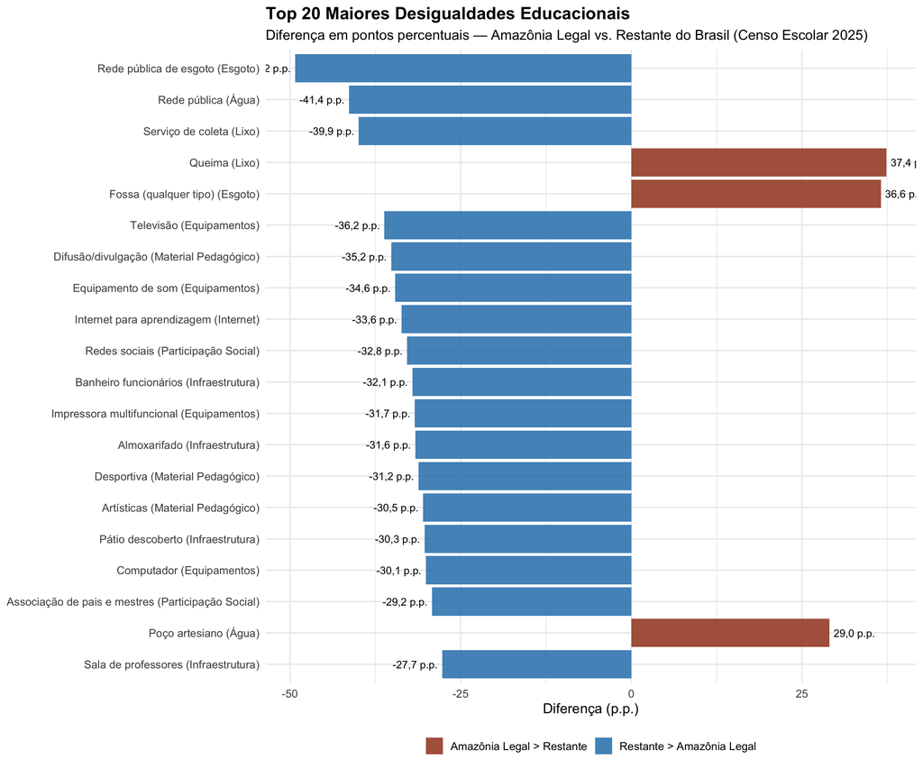

# 14. Análise por UF da Amazônia Legal

[figure not shown]

# 15. Considerações Metodológicas

**Fonte dos dados:** Microdados do Censo Escolar 2025, publicados pelo INEP.

**Universo:** 138.086 escolas de educação básica em funcionamento (TP_SITUACAO_FUNCIONAMENTO = 1).

**Recorte territorial:** Amazônia Legal definida no nível municipal, utilizando a classificação oficial do IBGE presente na base do PIB dos Municípios 2010-2023. São 772 municípios distribuídos em 9 UFs (AC, AP, AM, MA, MT, PA, RO, RR, TO), sendo que no Maranhão apenas 181 dos 217 municípios pertencem à Amazônia Legal, e no Mato Grosso há um pequeno número de municípios excluídos. Essa abordagem é mais precisa que a classificação simplesmente por UF.

**Cálculo das proporções:**

- **Variáveis binárias (IN_*):** Proporção = nº de escolas com valor 1 / total de escolas na região × 100.
- **Variáveis de proporção (QT_* / QT_*_TOTAL):** Soma da variável na região / soma do total na região × 100. Este é um cálculo **agregado** (não média de proporções por escola), o que evita viés de escolas pequenas.
- **Variáveis de média (QT_*):** Média aritmética simples por escola dentro da região.

**Barras visuais:** Barra vermelha = Amazônia Legal; barra azul = Restante do País. Comprimento proporcional ao valor máximo na tabela.

**Limitações:** Dados agregados por escola não permitem análise no nível individual do aluno. Variáveis como distorção idade-série não estão disponíveis nos microdados agregados.